# Session 9 Regression and Classification - Report Exerise

Tino Schneidewind

2025-05-24

## Stepwise forward regression

The objective of this report exercise is to display a stepwise forward regression modeling Gross Primary Production (GPP) as a function of all predictors available in the half-hourly ecosystem flux [dataset](https://raw.githubusercontent.com/geco-bern/agds_book/refs/heads/main/book/data/df_for_stepwise_regression.csv) (Table 1). For further information, see the [FLUXNET website](https://fluxnet.org/data/fluxnet2015-dataset/).

```r
# load libraries
library(tidyverse);library(rlang);library(gridExtra);library(knitr);library(kableExtra);library(dplyr)

# load data
half_hourly_fluxes <- readr::read_csv("../data/df_for_stepwise_regression.csv")|>
  select(-starts_with("TIMESTAMP"))  |>    # exclude time series
  mutate(siteid = as.factor(siteid)) |>    # SiteID as factor
  drop_na()                                # remove incomplete rows

# for reproducability
set.seed(1111999)
```

Table 1: Variables

|  | Variable | Description | Class |
| --- | --- | --- | --- |
| GPP_NT_VUT_REF | Gross Primary Production | numeric | μmol CO2 /m² s |
| siteid | Identification of site | factor | unitless |
| TA_F | Air temperature | numeric | °C |
| TA_F_MDS | Air temperature (gap filled) | numeric | °C |
| SW_IN_F | Incoming shortwave radiation | numeric | W/m² |
| SW_IN_F_MDS | Incoming shortwave radiation (gap filled) | numeric | W/m² |
| LW_IN_F | Incoming longwave radiation | numeric | W/m² |
| LW_IN_F_MDS | Incoming longwave radiation (gap filled) | numeric | W/m² |
| VPD_F | Vapor pressure deficit | numeric | hPa |
| VPD_F_MDS | Vapor pressure deficit (gap filled) | numeric | hPa |
| PA_F | Atmospheric pressure | numeric | kPa |
| P_F | Precipitation | numeric | mm |
| WS_F | Wind speed | numeric | m/s |
| CO2_F_MDS | CO2 mole fraction (gap filled) | numeric | unitless |
| PPFD_IN | Photosynthetic photon flux density | numeric | μmol Photon/m² s |
| USTAR | Friction velocity | numeric | unitless |

### 1. Introduction

Gross Primary Production (GPP; variable: GPP_NT_VUT_REF) refers to the total amount of organic carbon assimilated by vegetation through photosynthesis. GPP is a key component in understanding ecosystem productivity and carbon cycling, both of which are particularly important in the context of climate change.

GPP is influenced by environmental conditions such as light availability (intensity, duration, seasonality), temperature (which affects enzyme activity), and water availability (impacting photosynthesis and stomatal openings during drought). It is also influenced by biotic factors like plant species (leaf area), succession (growth periods), and interactions with herbivores or disease (which can decrease biomass).

To accurately model GPP, it is crucial to understand its predictors. The following research questions guide my investigation:

1. What is the best single linear predictor of GPP?
2. How can GPP be predicted most effectively using all available variables in a linear model?

For both objectives, I will use the $R^2$ and Akaiken information criterion (AIC) as measures of predictive performance.

### 2. Methods

To investigate which single variables predicts GPP best, I fit linear models for each bivariate combination with GPP as the outcome and compare their $R^2$ and AIC scores.

To assess how GPP can be best modeled using a combination of all possible predictors I performed a stepwise forward regression, as this is a very computationally efficient, following these steps:

1. Set the number of predictors to $p = 1$.
2. Fit all regression models with $p$ predictor(s) and compute their $R^2$.
3. Select the model with $p$ predictor(s) that achieves the highest $R^2$ (best fitting model) and compute its AIC.
4. Fit all regression models with $p + 1$ predictors that includes the predictor(s) selected at the previous step and compute their $R^2$. Select the best fitting model and compute its AIC.
5. If the AIC of the model with $p + 1$ predictors is poorer than the AIC of the model with $p$ predictor(s), retain the model with $p$ predictor(s) and quit. Otherwise, continue with with step 4.

In this stepwise forward regression, I accounted for all the variables displayed in Table 1.

Using the following function, I calculated the capacity of the linear models to predict GPP, using $R^2$, adjusted $R^2$, and AIC.

```r
# function to extract model performance
fit_model <- function(var) {

  # define formula and model
  formula_mod <- as.formula(paste0("GPP_NT_VUT_REF ~ ", var))
  mod         <- lm(formula = formula_mod, data = half_hourly_fluxes)

  # extract predictive performance
  tibble(
    predictor  = var,
    R2         = summary(mod)$r.squared,
    R2adj      = summary(mod)$adj.r.squared,
    AIC        = extractAIC(mod)[2]
  )
}
```

For research question 1, I determined the predictive performance of GGP of all variables individually.

```r
# predictor names for bivariate analysis
vars      <- colnames(half_hourly_fluxes |> select(-starts_with("GPP")))

# apply function
results_1 <- map_dfr(vars, fit_model) |> arrange(desc(R2))
```

To implement the stepwise forward regression, I created a for loop based on the previously described steps that only stops when the newest best-performing model is not performing better compared to the one with one less predictor.

```r
# empty data frame to save model performances
stepwise <- data.frame(predictor = " ",
                      R2 = 0,
                      R2adj = 0,
                      AIC = Inf)

# if the NEW MODEL (the bottom one because rbind) is NOT THE BEST -> STOP
while(min(stepwise$AIC) == stepwise$AIC[nrow(stepwise)]){

  # get individual predictors off all previous models so that
  # I can exclude them from future multiple predictor models
  stepwise_split <- unlist(strsplit(stepwise$predictor, " "))

  # apply fit_model to the all possible combinations with the previous BEST PERFOMING MODEL
  results_2      <- map_dfr(paste0(stepwise$predictor[nrow(stepwise)]," + ", setdiff(vars, stepwise_split)),
                            fit_model)

  # extract and save the best performing NEW MODEL from results
  stepwise       <- rbind(stepwise, results_2[results_2$AIC == min(results_2$AIC),])
}
```

After running this loop, I delete the first row, which has no predictors and the last row, which performed worse than the previous row.

```r
# clean up the dataframe
stepwise <- stepwise |>

  # remove first (empty) and last (not best) performing model
  slice(2:(n() - 1)) |>

  # remove " + " at the start of predictors
  mutate(predictor = substr(predictor, 5, nchar(predictor)),
         index = seq_along(predictor)) |>

  # reorder the data frame
  select(index, everything())
```

### 3. Results

#### 3.1. Single linear predictors

From all single linear predictors, photosynthetic photon flux density (PPFD_IN) was the most effective in predicting GPP, with an $R^2$ of 0.363, which indicates a moderate but limited capacity to predict GPP with 63.7% of the variance of GPP remaining unexplained (Table 2). Second and third best in predicting GPP were incoming shortwave radiation (SW_IN_F and SW_IN_F_MDS) and air temperature (TA_F and TA_F_MDS) with the gap-filled variables being able to better predict GPP than their non-gap-filled counterparts. Apart from these top 5 predicting variables, all other variables had very low $R^2$ values that indicate very poor predictability of GPP based on these variables individually.

Table 2: Model Performance Metrics

| Index | Predictor | R² | AIC |
| --- | --- | --- | --- |
| 1 | PPFD_IN | 0.363 | 18738.19 |
| 2 | SW_IN_F_MDS | 0.350 | 18920.69 |
| 3 | SW_IN_F | 0.350 | 18921.99 |
| 4 | TA_F_MDS | 0.277 | 19941.97 |
| 5 | TA_F | 0.277 | 19942.17 |
| 6 | VPD_F | 0.118 | 21824.85 |
| 7 | LW_IN_F_MDS | 0.116 | 21842.05 |
| 8 | LW_IN_F | 0.114 | 21864.72 |
| 9 | VPD_F_MDS | 0.112 | 21894.14 |
| 10 | siteid | 0.064 | 22394.15 |
| 11 | CO2_F_MDS | 0.050 | 22528.37 |
| 12 | WS_F | 0.012 | 22899.17 |
| 13 | P_F | 0.003 | 22988.40 |
| 14 | PA_F | 0.000 | 23013.89 |
| 15 | USTAR | 0.000 | 23016.33 |

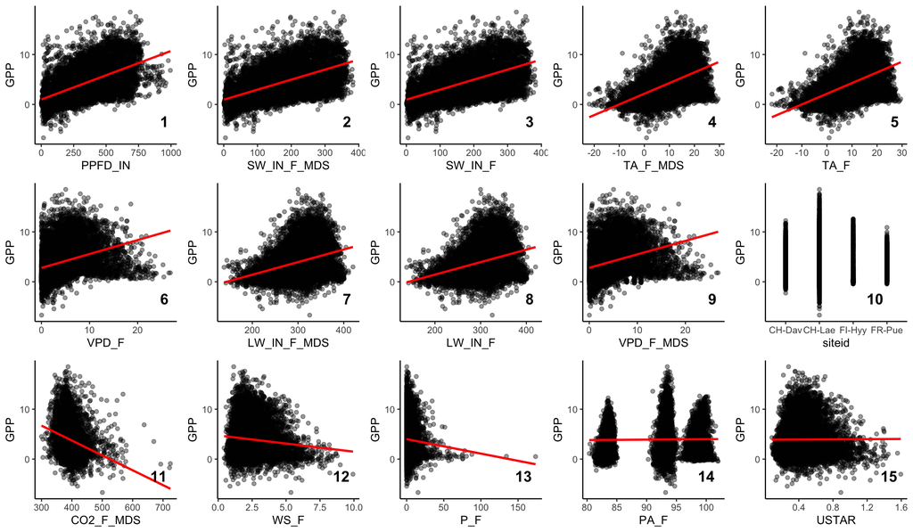

*Figure 1: Scatterplots of all predictors and GPP and their linear association.* 1*: PPFD_IN*; 2*: SW_IN_MDS*; 3*: SW_IN_F*; 4*: TA_F_MDS*; 5*: TA_F*; 6*: VPD_F*; 7*: LW_IN_F_MDS*; 8*: LW_IN_F*; 9*: VPD_F_MDS*; 10*: siteid*; 11*: CCO2_F_MDS*; 12*: WS_F*; 13*: P_F*; 14*: PA_F*; 15*: USTAR.*

Figure 1 displays scatterplots of all single predictors of GPP. A clear positive correlation is shown between GPP and the five best predictors identified in Table 2: PPFD_IN, SW_IN_F, SW_IN_F_MDS, TA_F, and TA_F_MDS. In contrast, the remaining variables show a poor relationship with GPP, as evidenced by the uniform cloud patterns in their scatterplots. Notably, the two variables siteid and PA_F exhibited distinct patterns that reflect the influence of different measurement stations.

#### 3.2. Stepwise forward regression

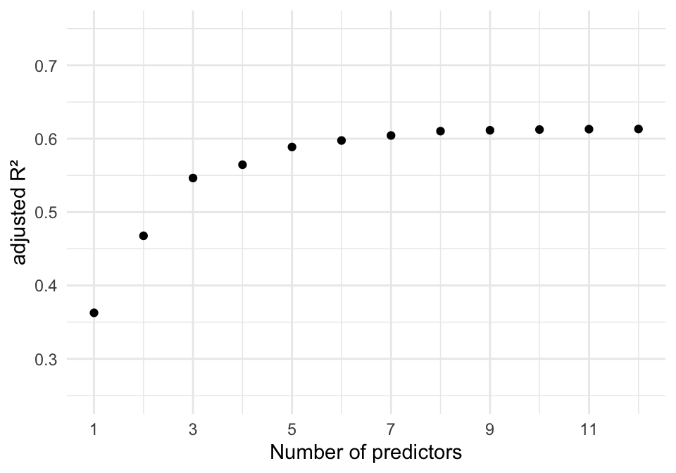

*Figure 2: Adjusted $R^2$ scores for the best performing model with a defined number of predictors from the stepwise regression.*

Investigating the increased predictive ability based on the number of predictors, the iterative addition of predictors initially increased the capability of GPP prediction (Figure 2). However, after three predictors, the improvement from adding additional predictors decreased. By the time five predictors were added, the increase in adjusted R2 became minimal.

Examining the variables determined in the stepwise forward regression in Table 3, we found that PPFD_IN, the previously identified best single predictor, was most effectively improved in predictive capacity by siteid, the only categorical variable in the data set. Additional meaningful improvements in GPP modeling were achieved by successively adding longwave incoming radiation (LW_IN_F) and gap-filled vapor pressure deficit (VPD_F_MDS). Interestingly, of the top five single predictors, gap-filled air temperature (TA_F_MDS) was only added in the fifth iteration of the stepwise regression. This delayed inclusion suggests a high correlation between TA_F_MDS, the other best-performing predictors from Table 2, and PPFD_IN, as they potentially explain a similar variation of GPP.

Table 3: Stepwise Regression Model Performance Metrics

| Index | Predictor | R2 | R2adj | AIC |
| --- | --- | --- | --- | --- |
| 1 | PPFD_IN | 0.3628 | 0.3627 | 18738.19 |
| 2 | PPFD_IN + siteid | 0.4679 | 0.4676 | 17033.14 |
| 3 | PPFD_IN + siteid + LW_IN_F | 0.5467 | 0.5464 | 15513.39 |
| 4 | PPFD_IN + siteid + LW_IN_F + VPD_F_MDS | 0.5648 | 0.5645 | 15128.21 |
| 5 | PPFD_IN + siteid + LW_IN_F + VPD_F_MDS + TA_F_MDS | 0.5890 | 0.5887 | 14586.33 |
| 6 | PPFD_IN + siteid + LW_IN_F + VPD_F_MDS + TA_F_MDS + SW_IN_F | 0.5979 | 0.5976 | 14380.61 |
| 7 | PPFD_IN + siteid + LW_IN_F + VPD_F_MDS + TA_F_MDS + SW_IN_F + WS_F | 0.6048 | 0.6044 | 14219.39 |
| 8 | PPFD_IN + siteid + LW_IN_F + VPD_F_MDS + TA_F_MDS + SW_IN_F + WS_F + USTAR | 0.6107 | 0.6103 | 14078.01 |
| 9 | PPFD_IN + siteid + LW_IN_F + VPD_F_MDS + TA_F_MDS + SW_IN_F + WS_F + USTAR + VPD_F | 0.6120 | 0.6115 | 14049.09 |
| 10 | PPFD_IN + siteid + LW_IN_F + VPD_F_MDS + TA_F_MDS + SW_IN_F + WS_F + USTAR + VPD_F + CO2_F_MDS | 0.6129 | 0.6125 | 14027.07 |
| 11 | PPFD_IN + siteid + LW_IN_F + VPD_F_MDS + TA_F_MDS + SW_IN_F + WS_F + USTAR + VPD_F + CO2_F_MDS + PA_F | 0.6135 | 0.6130 | 14014.40 |
| 12 | PPFD_IN + siteid + LW_IN_F + VPD_F_MDS + TA_F_MDS + SW_IN_F + WS_F + USTAR + VPD_F + CO2_F_MDS + PA_F + P_F | 0.6138 | 0.6132 | 14009.66 |

## Discussion

The results from this analysis provide valuable insights into the modeling of GPP using a variety of environmental predictors. The evaluation of single predictors demonstrated that photosynthetic photon flux density was the most effective variable for predicting GPP, with a moderate $R^2$ of 0.363. This highlights the importance of light availability in driving photosynthesis and carbon assimilation in vegetation. The gap-filled versions of incoming shortwave radiation and air temperature predicted GPP only slightly worse, demonstrating the dependency of photosynthesis on both and the potential benefit of gap-filling for improving the accuracy of environmental data, especially in data sets with missing values. On the other hand, the remaining variables showed very poor predictive power, suggesting that not all environmental predictors contribute equally to accurate GPP modeling on their own.

When applying the stepwise forward regression, the iterative addition of predictors initially improved the model’s predictive accuracy, as reflected by the increasing $R^2$. However, after the inclusion of three predictors, the improvement from adding additional variables became smaller, and by the time five predictors were included, the adjusted $R^2$ barely improved with more predictors. This phenomenon is consistent with the diminishing returns of adding predictors, where each additional variable explains progressively less of the variation in GPP.

The choice of variables in the final stepwise model reveals important relationships between predictors. Photosynthetic photon flux density continued to play a central role, and its predictive capacity was further enhanced by the inclusion of the measurement site, which suggests that variability between measurement stations is an important factor influencing GPP. Other predictors such as incoming longwave radiation and vapor pressure deficit contributed meaningfully to the model, improving the overall prediction of GPP. Interestingly, gap-filled air temperature was only included in the fifth iteration of the regression, which likely reflects its high correlation with the other variables, particularly photosynthetic photon flux density. The delayed inclusion of gap filled air temperature and other well performing single predictors of GPP reinforces the idea that these predictors share overlapping information and that stepwise selection can help identify the most informative set of variables for modeling GPP.

It is important to note that the models presented here are linear models, which assume a linear relationship between the predictors and the response variable, GPP. While linear models are computationally efficient and easy to interpret, they may not capture complex non-linear relationships between variables. Future work could explore non-linear models or include interaction terms to better capture these relationships.